# Formalia:

Please read the [assignment overview page](https://github.com/suneman/socialgraphs2017/wiki/Assignments) carefully before proceeding. This page contains information about formatting (including formats etc), group sizes, and many other aspects of handing in the assignment.

*If you fail to follow these simple instructions, it will negatively impact your grade!*

**Due date and time**: The assignment is due on Tuesday October 3rd at 23:55. Hand in your IPython notebook file (with extension `.ipynb`) via http://peergrade.io/.

# Part One: Network Models

## Watts-Strogatz Networks

- Use `nx.watts_strogatz_graph` to generate 3 graphs with 500 nodes each, average degree = 4, and rewiring probablity $p = 0, 0.1, \textrm{and} 1$. Calculate the average shortest path length $\langle d \rangle$ for each one. Describe what happens to the network when $p = 1$.

```python
import networkx as nx
graph0 = nx.watts_strogatz_graph(n=500, k=4, p=0)
graph0_1 = nx.watts_strogatz_graph(n=500, k=4, p=0.1)
graph1 = nx.watts_strogatz_graph(n=500, k=4, p=1)

print nx.average_shortest_path_length(graph0)
print nx.average_shortest_path_length(graph0_1)
print nx.average_shortest_path_length(graph1)
```

```
62.875751503
7.70920240481
4.73822044088
```

- Let's understand the behavior of the WS model as we increase *p* in more detail.. Generate 50 networks with $N = 500$, $\langle k \rangle = 4$, for each of $p = \{0, 0.01, 0.03, 0.05, 0.1, 0.2\}$. Calculate the average of $\langle d \rangle$ as well as the standard deviation over the 50 networks, to create a plot that shows how the path length decreases very quickly with only a little fraction of re-wiring. Use the standard deviation to add errorbars to the plot. My version of the plot is below (since a picture's worth 1000 words).

[figure not shown]

```python
import numpy as np
def graph_solver(p):
    graph = []
    graph[0:50] = [nx.watts_strogatz_graph(n=500, k=4, p=p) for i in range(50)]
    d = [nx.average_shortest_path_length(i) for i in graph]
    ave_d = sum(d) / len(graph)
    ave_stds = np.std(d)
    print "average distance: ", ave_d
    print "average std: ", ave_stds
    print '\n'
    return ave_d, ave_stds

p = [0,0.01,0.03,0.05,0.1,0.2]
result = {'ave_d' : [], 'ave_stds' : []}
for i in p:
    print "Probability : ", i
    ave_d, ave_stds = graph_solver(i)
    result['ave_d'].append(ave_d)
    result['ave_stds'].append(ave_stds)
```

```
Probability :  0
average distance:  62.875751503
average std:  7.1054273576e-15


Probability :  0.01
average distance:  23.7074738277
average std:  4.12022885093


Probability :  0.03
average distance:  12.9637301804
average std:  1.05740339312


Probability :  0.05
average distance:  10.2757946293
average std:  0.630095426333


Probability :  0.1
average distance:  7.73349867735
average std:  0.341999333712


Probability :  0.2
average distance:  6.08271358717
average std:  0.0929831189009
```

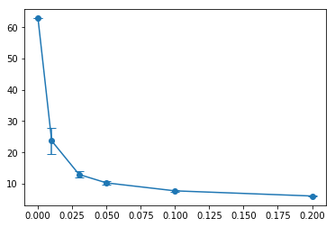

```python
#!/usr/bin/env python
import numpy as np
import matplotlib.pyplot as plt

# example data
p = [0,0.01,0.03,0.05,0.1,0.2]

plt.figure()
plt.errorbar(p, result['ave_d'], yerr=result['ave_stds'], fmt="-o", capsize=5)
plt.show()
```

## The Barabasi-Albert Model

We're going to create our own Barabasi-Albert model (a special case) in right in a `notebook`. Follow the recipe below for success

- Create a 100 node BA network using a BA model that you've coded on your own (so don't use the built-in NetworkX function, but the one you created during week 3). And plot it using NetworkX.

```python
import numpy

def graph_drawer(graph):
    flatten_edges = np.array(graph.edges()).flatten()
    unique, counts = numpy.unique(flatten_edges, return_counts=True)
    proportion_list = counts/float(sum(counts))
    chosen_node = np.random.choice(graph.nodes(), p=proportion_list)
    graph.add_node(len(graph)+1)
    graph.add_edge(len(graph), chosen_node)
    return graph

graph = nx.Graph()
graph.add_nodes_from([1,2])
graph.add_edge(1,2)

for i in range(100):
    graph = graph_drawer(graph)
```

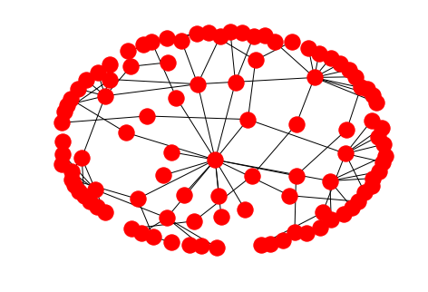

```python
import warnings
warnings.filterwarnings("ignore")

nx.draw(graph)
plt.show()
```

- Now create a 5000 node network.
  - What's the maximum and minimum degree?
  - Now, bin the degree distribution, for example using `numpy.histogram`.
  - Plot the distribution. Plot it with both linear and log-log axes.

[figure not shown]

```python
while len(graph.nodes()) < 5000 :
    graph = graph_drawer(graph)
```

```python
degree_values = graph.degree().values()
min_deg = min(degree_values)
max_deg = max(degree_values)
print 'minimum degree : ', min_deg
print 'maximum degree : ', max_deg
```

```
minimum degree :  1
maximum degree :  112
```

```python
hist,bins = np.histogram(degree_values, range(min_deg, max_deg))
degrees_sorted = sorted(degree_values)
degree_hist = [degrees_sorted.count(x) for x in degrees_sorted]
```

```python
hist
```

```
array([3329,  833,  340,  175,   81,   60,   37,   36,   16,   15,    8,
         10,    8,    3,    5,    3,    3,    6,    6,    4,    2,    1,
          2,    0,    3,    0,    1,    1,    0,    1,    1,    0,    0,
          0,    1,    1,    2,    0,    1,    0,    0,    0,    0,    0,
          0,    0,    1,    0,    0,    1,    0,    0,    0,    0,    0,
          0,    0,    0,    0,    0,    0,    0,    0,    0,    0,    0,
          0,    0,    1,    0,    0,    0,    0,    0,    0,    0,    0,
          0,    0,    0,    0,    0,    0,    1,    0,    0,    0,    0,
          0,    0,    0,    0,    0,    0,    0,    0,    0,    0,    0,
          0,    0,    0,    0,    0,    0,    0,    0,    0,    0,    0], dtype=int64)
```

```python
bins
```

```
array([  1,   2,   3,   4,   5,   6,   7,   8,   9,  10,  11,  12,  13,
        14,  15,  16,  17,  18,  19,  20,  21,  22,  23,  24,  25,  26,
        27,  28,  29,  30,  31,  32,  33,  34,  35,  36,  37,  38,  39,
        40,  41,  42,  43,  44,  45,  46,  47,  48,  49,  50,  51,  52,
        53,  54,  55,  56,  57,  58,  59,  60,  61,  62,  63,  64,  65,
        66,  67,  68,  69,  70,  71,  72,  73,  74,  75,  76,  77,  78,
        79,  80,  81,  82,  83,  84,  85,  86,  87,  88,  89,  90,  91,
        92,  93,  94,  95,  96,  97,  98,  99, 100, 101, 102, 103, 104,
       105, 106, 107, 108, 109, 110, 111])
```

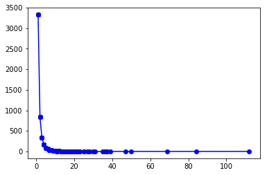

```python
plt.plot(degrees_sorted, degree_hist, 'bo-')
plt.show()
```

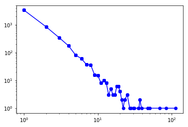

```python
plt.loglog(degrees_sorted, degree_hist, 'bo-')
plt.show()
```

## Power-laws and the friendship paradox

Next step is to explore the [Friendship paradox](https://en.wikipedia.org/wiki/Friendship_paradox). This paradox states that *almost everyone* have fewer friends than their friends have, on average. This sounds crazy, but is actually an almost trivial consequence of living in a social network with a power-law degree distribution. The explanation is that almost everyone is friends with a hub, that drives up the average degree of the friends. Let's explore that in the 5000 node BA network we've just generated. Do the following:

- Pick a node *i* at random (e.g. use `random.choice`). [Find its degree](http://networkx.lanl.gov/reference/generated/networkx.Graph.degree.html).
- Find *i*'s [neighbors](http://networkx.lanl.gov/reference/generated/networkx.Graph.neighbors.html). And calculate their average degree.
- Compare the two numbers to check if it's true that *i*'s friends (on average) have more friends than *i*.
- Do this 1000 times. How many out of those 1000 times is the friendship paradox true?

```python
true_count = 0
for i in range(1000):
    chosen = np.random.choice(graph.nodes())
    neighbors = graph.neighbors(chosen)
    if graph.degree(chosen) < np.mean([graph.degree(i) for i in neighbors]):
        true_count += 1

print 'true count that i\'s friends (on average) have more friends than i: ', true_count
```

```
true count that i's friends (on average) have more friends than i:  857
```

# Part Two: The Wikipedia Philosopher's network

This exercise assumes that you have downloaded and created the directed network of philosophers on Wikipedia, based on the six branches of philosophy on you own.

## Basic stats

First put together an overview of the 7 lists you created as part of lecture 4.

- Let's put together some descriptive statistics:
  - How many philosophers in each list? How many total?
  - Which is the largest branch of philosophy? (according to number of Wikipedia philosopher-pages)

```python
# Make it as function
import urllib
import re

def listWikiPhilos(link, deduction=0):
    # Crawl
    if "en.wikipedia.org" in link:
        # Link
        response = urllib.urlopen(link)
    else:
        # Keyword
        response = urllib.urlopen("http://en.wikipedia.org/wiki/"+ link)
    wikiData = response.read()

    # Analyze with Regex
    if deduction:
        philosList = re.findall(r'<li><a href=\"/wiki/([^>]+)" [^>]+>([^>]+)</a', wikiData)[:-deduction]
    else:
        philosList = re.findall(r'<li><a href=\"/wiki/([^>]+)" [^>]+>([^>]+)</a', wikiData)
    return philosList
```

```python
aestheticians_1_2 = listWikiPhilos("List_of_aestheticians", 2)
epistemologists_2_99 = listWikiPhilos("List_of_epistemologists", 99)
ethicists_3_111 = listWikiPhilos("List_of_ethicists", 111)
logicians_4_53 = listWikiPhilos("List_of_logicians", 53)
metaphysicians_5_138 = listWikiPhilos("List_of_metaphysicians", 138)
sociopoliticals_6_197 = listWikiPhilos("List_of_social_and_political_philosophers", 197)
```

```python
print "last : ", aestheticians_1_2[-1], '\t # of phils: ', len(aestheticians_1_2)
print "last : ", epistemologists_2_99[-1], ' # of phils: ', len(epistemologists_2_99)
print "last : ", ethicists_3_111[-1], '\t # of phils: ', len(ethicists_3_111)
print "last : ", logicians_4_53[-1], '\t # of phils: ', len(logicians_4_53)
print "last : ", metaphysicians_5_138[-1], '\t\t # of phils: ', len(metaphysicians_5_138)
print "last : ", sociopoliticals_6_197[-1], '\t\t # of phils: ', len(sociopoliticals_6_197)
```

```
last :  ('Richard_Wollheim', 'Richard Wollheim') 	 # of phils:  122
last :  ('James_Frederick_Ferrier', 'James Frederick Ferrier')  # of phils:  99
last :  ('List_of_economists', 'list of economists') 	 # of phils:  271
last :  ('Alexander_Zinoviev', 'Alexander Zinoviev') 	 # of phils:  274
last :  ('Xavier_Zubiri', 'Xavier Zubiri') 		 # of phils:  96
last :  ('Zhuang_Zhou', 'Zhuangzi') 		 # of phils:  333
```

```python
philosophers = (set(aestheticians_1_2)
    .union(set(epistemologists_2_99))
    .union(set(ethicists_3_111))
    .union(set(logicians_4_53))
    .union(set(metaphysicians_5_138))
    .union(set(sociopoliticals_6_197)))
```

```python
print 'total # of philosophers: ', len(philosophers)
```

```
total # of philosophers:  1045
```

```python
print 'the largest branch: sociopoliticals'
print 'number of philosophers in the largest branch: ', len(sociopoliticals_6_197)
```

```
the largest branch: sociopoliticals
number of philosophers in the largest branch:  333
```

- Which philosopher is in most lists & and how many?
- Let's investigate philosophers active in multiple sub-fields in more detail.
  - Create a list of every philosopher that occurs in more than one list.
  - Use Python to sort the list according to how many lists each philosopher belongs to (so the guy you found in the previous question is first in that list).
  - Print the top 5 guys and their list counts. Have you heard of any of them?

```python
def philosCount(philosSet, philosCategories):
    philos_count = {}
    for philo in philosSet:
        philo_count = 0
        for philosCategory in philosCategories:
            if philo in philosCategory:
                philo_count += 1

        philos_count[philo] = philo_count

    return philos_count
```

```python
philosCategories = [aestheticians_1_2,
                    epistemologists_2_99,
                    ethicists_3_111,
                    logicians_4_53,
                    metaphysicians_5_138,
                    sociopoliticals_6_197]
philosCount = philosCount(philosophers, philosCategories)
```

```python
class ModeError(Exception):
    pass


def freqPhilos(philosCount, mode='max', freq_count=2):
    if mode == 'max':
        max_count = max(philosCount.values())
    elif mode == 'freq':
        pass
    else:
        raise ModeError("Error message : Incorrect Mode")
        return -1
    freqPhilos = []
    for idx, philo in enumerate(philosCount):
        if mode == 'max':
            if philosCount[philo] == max_count:
                freqPhilos.append(philo)
        elif mode == 'freq':
            if philosCount[philo] >= freq_count:
                freqPhilos.append([philo, philosCount[philo]])

    if mode == 'max':
        return freqPhilos, max_count
    elif mode == 'freq':
        return freqPhilos


freqPhilos= freqPhilos(philosCount, 'freq', 2)
print freqPhilos
```

```
[[('Catherine_Elgin', 'Catherine Elgin'), 2], [('Ayn_Rand', 'Ayn Rand'), 3], [('Emma_Goldman', 'Emma Goldman'), 2], [('Walter_Benjamin', 'Walter Benjamin'), 2], [('S%C3%B8ren_Kierkegaard', 'S\xc3\xb8ren Kierkegaard'), 3], [('Thomas_Hill_Green', 'Thomas Hill Green'), 2], [('Karl-Otto_Apel', 'Karl-Ott…
```

```python
def getKey(item):
    return item[1]

philosbyfreq = sorted(freqPhilos, key=getKey, reverse=True)
```

```python
philosbyfreq
```

```
[[('Aristotle', 'Aristotle'), 6],
 [('Bertrand_Russell', 'Bertrand Russell'), 5],
 [('Immanuel_Kant', 'Immanuel Kant'), 5],
 [('Plato', 'Plato'), 5],
 [('David_Hume', 'David Hume'), 4],
 [('Thomas_Aquinas', 'Thomas Aquinas'), 4],
 [('Ayn_Rand', 'Ayn Rand'), 3],
 [('S%C3%B8ren_Kierkegaard', 'S\xc3\xb8ren Kierkegaard'), 3],
 [('Arthur_Schopenhauer', 'Arthur Schopenhauer'), 3],
 [('Francis_Bacon', 'Francis Bacon'), 3],
 [('Ludwig_Wittgenstein', 'Ludwig Wittgenstein'), 3],
 [('Nelson_Goodman', 'Nelson Goodman'), 3],
 [('Baruch_Spinoza', 'Baruch Spinoza'), 3],
 [('Judith_Butler', 'Judith Butler'), 3],
 [('Georg_Wilhelm_Friedrich_Hegel', 'Georg Wilhelm Friedrich Hegel'), 3],
 [('Mario_Bunge', 'Mario Bunge'), 3],
 [('John_Stuart_Mill', 'John Stuart Mill'), 3],
 [('John_Locke', 'John Locke'), 3],
 [('Robert_Nozick', 'Robert Nozick'), 3],
 [('Susan_Haack', 'Susan Haack'), 3],
 [('Catherine_Elgin', 'Catherine Elgin'), 2],
 [('Emma_Goldman', 'Emma Goldman'), 2],
 [('Walter_Benjamin', 'Walter Benjamin'), 2],
 [('Thomas_Hill_Green', 'Thomas Hill Green'), 2],
 [('Karl-Otto_Apel', 'Karl-Otto Apel'), 2],
 [('Martin_Luther_King,_Jr." class="mw-redirect', 'Martin Luther King, Jr.'),
  2],
 [('Philip_Pettit', 'Philip Pettit'), 2],
 [('Martin_Heidegger', 'Martin Heidegger'), 2],
 [('Ruth_Barcan_Marcus', 'Ruth Barcan Marcus'), 2],
 [('Friedrich_Schiller', 'Friedrich Schiller'), 2],
 [('Michael_Oakeshott', 'Michael Oakeshott'), 2],
 [('Thomas_Nagel', 'Thomas Nagel'), 2],
 [('Mao_Zedong', 'Mao Zedong'), 2],
 [('Edward_Said', 'Edward Said'), 2],
 [('Murray_Rothbard', 'Murray Rothbard'), 2],
 [('George_Berkeley', 'George Berkeley'), 2],
 [('John_Searle', 'John Searle'), 2],
 [('G._E._Moore', 'G. E. Moore'), 2],
 [('William_of_Ockham', 'William of Ockham'), 2],
```

[output cut: 64 more lines]

```
 [('John_Rawls', 'John Rawls'), 2],
 [('Robert_S._Hartman', 'Robert S. Hartman'), 2],
 [('Penelope_Maddy', 'Penelope Maddy'), 2],
 [('J%C3%BCrgen_Habermas', 'J\xc3\xbcrgen Habermas'), 2],
 [('Max_Stirner', 'Max Stirner'), 2],
 [('Alfred_North_Whitehead', 'Alfred North Whitehead'), 2],
 [('Ren%C3%A9_Descartes', 'Ren\xc3\xa9 Descartes'), 2],
 [('Henry_Sidgwick', 'Henry Sidgwick'), 2],
 [('Michel_Onfray', 'Michel Onfray'), 2],
 [('Hilary_Putnam', 'Hilary Putnam'), 2],
 [('David_Kolb', 'David Kolb'), 2],
 [('Martha_Nussbaum', 'Martha Nussbaum'), 2],
 [('Saul_Kripke', 'Saul Kripke'), 2],
 [('George_Boole', 'George Boole'), 2],
 [('Karl_Popper', 'Karl Popper'), 2]]
```

```python
philosbyfreq[:5]
```

```
[[('Aristotle', 'Aristotle'), 6],
 [('Bertrand_Russell', 'Bertrand Russell'), 5],
 [('Immanuel_Kant', 'Immanuel Kant'), 5],
 [('Plato', 'Plato'), 5],
 [('David_Hume', 'David Hume'), 4]]
```